# Problem Set 03

Author

Ruth Williamson: Group 4

Published

February 9, 2026

```r
library(tidyverse)
library(readxl)
library(ggplot2)
```

## Size Dimorphism in Spiders

Sexual size dimorphism (SSD) refers to the difference in size between males and females of the same species. Spiders show some of the most dramatic cases where females are larger than males.

The golden silk orb weaver (*Nephila clavipes*) is a species of spider that shows extreme SSD, in which males are about 2/3 smaller than females. This picture shows the size disparity between a female and male:

[figure not shown]

In contrast, in the wolf spider (*Pardosa ramulosa*), males and females do not show large size differences.

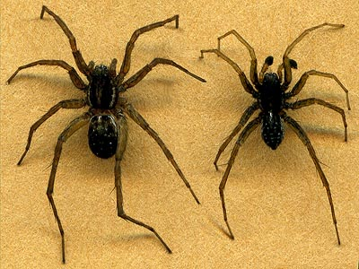

The file `Size_Dimorphism.xlsx` contains data on body mass and body length for males and females in these two species.

## Data Validation and Cleaning

One of the first steps in analysis is to make sure that the data you loaded into R is the data that you think you recorded, that all the groups are present in the correct counts, that there aren’t any data entry errors, etc.

### Activity

Using the `read_excel()` function from the `readxl` package (install if you need to), load the file `Size_Dimorphism.xlsx` in R. Assign it to the object, `SSD`.

```r
SSD <- read_excel("Size_Dimorphism.xlsx")

glimpse(SSD)
```

```
Rows: 200
Columns: 5
$ ID         <dbl> 1, 2, 3, 4, 5, 6, 7, 8, 9, 10, 11, 12, 13, 14, 15, 16, 17, …
$ Species    <chr> "Pardosa_ramulosa", "Pardosa_ramulosa", "Pardosa_ramulosa",…
$ Sex        <chr> "M", "M", "M", "M", "M", "M", "M", "M", "M", "M", "M", "M",…
$ BodyLength <dbl> 3.673, 4.964, 5.213, 5.178, 4.794, 6.045, 3.967, 2.754, 4.2…
$ BodyMass   <dbl> 0.053, 0.168, 0.223, 0.106, 0.146, 0.220, 0.098, 0.024, 0.0…
```

How many rows and columns of data are there in `SSD`?

> 200 rows and 5 columns

## Number of Observations per Group

This experiment is balanced, meaning there are equal numbers of males and females in each of two species (50 in each sex/species combination).

#### Activity

Check that this is the case by using `count()` to count the number of individuals by species and sex.

```r
SSD |>
  count(Species, Sex)
```

```
# A tibble: 9 × 3
  Species          Sex       n
  <chr>            <chr> <int>
1 Nephila_clavipes F        48
2 Nephila_clavipes M        50
3 Nephila_clavipes f         2
4 Pardosa ramulosa M         1
5 Pardosa_ramulosa F        48
6 Pardosa_ramulosa M        45
7 Pardosa_ramulosa f         2
8 Pardosa_ramulosa m         3
9 Pardosa_ramuloso M         1
```

It looks like something is not right. There are several rows with 1, 2, or 3 observations.

Explain what appears to have happened during data entry.

> Some of the sex designations are either capitalized or not capitalized and there are also some mis-spellings of some of the spider names.